# Predicting treatment effects with teff

Alejandro Caceres and Juan R. González

Instituto de Salud Global de Barcelona (ISGlobal), Barcelona, Spain  
Department of Mathematics, Escola d'Enginyeria de Barcelona Est (EEBE) Universitat Politècnica de Catalunya, Barcelona Spain.  
Department of Mathematics, Universitat Autònoma de Barcelona, Barcelona, Spain

alejandro.caceres@isglobal.org

3 marzo 2022

#### Package

teff 0.1.0

# 1 Introduction

`teff` is a software package to estimate the expected difference in the outcome of an individual between two treatments, given the individual’s profile in some feature data. The package focuses on transcriptomic features for which surrogate covariates need to be estimated. The estimation of individual treatment effects is based on inferences using Random Causal Forest as implemented in the package grf by Tibshirani et al.

Here, we show how to use the package to estimate transcriptomic profiles of psoriasis patients that at baseline are expected to have a higher response to brodalumab than placebo. Publicly available data has been downloaded from GEO for accession number GSE117468. This is data from a clinical trial of brodalumab treatment of psoriasis patients.

# 2 Analysis

```r
library(teff)
```

We ﬁrst obtained clinical data relating to age, BMI, psoriasis area-and-severity-index (PASI) at baseline and week 12 after treatment, and brodalumab or placebo treatment.

The psoriasis data set is a list that contains the  
teffdata with variables: eff for the outcome effect, namely the improvement of PASI score at week 12, where 1 encodes: improved PASI after treatment, and 0: did not improve PASI after treatment; t for treatment with 0:placebo, 1:brodalumab; and covariates such as age, bmi and cov5…, which are surrogate variables estimated for the transcription data, and associated to latent technical differences in their measurement. See [Case study](https://teff-package.github.io/teff/SupplementaryCaceres2021.html) for the complete workflow on how to obtain and format the data from GEO database.

```r
names(psoriasis)
```

```
## [1] "features" "teffdata"
```

```r
head(psoriasis$teffdata[,1:10])
```

```
##            t eff age    bmi        cov5        cov6         cov7        cov8
## GSM3300910 1   1  53 20.750 -0.03890177  0.03467942  0.043746932  0.17594309
## GSM3300916 0   1  51 35.235  0.14126324  0.10711059 -0.001265844 -0.06115758
## GSM3300920 0   0  47 35.471 -0.15755427  0.20506609 -0.079110601  0.07190374
## GSM3300928 1   1  38 33.272  0.04814467 -0.08004999 -0.165959371  0.03569621
## GSM3300932 0   0  47 36.553 -0.07157232 -0.11915946 -0.038394625 -0.04629123
## GSM3300936 0   0  64 32.189 -0.30802680 -0.09920047  0.043504869  0.04527702
##                   cov9        cov10
## GSM3300910 0.135287841 -0.177583007
## GSM3300916 0.122662569  0.030069280
## GSM3300920 0.078727884  0.105476906
## GSM3300928 0.009297803 -0.026598687
## GSM3300932 0.044703103 -0.009509721
## GSM3300936 0.061549094  0.094933813
```

The transcriptomic feature data contains the expression levels of 87 genes in non-lesional skin at baseline that were found significant in the differential expression analysis of the interaction between PASI improvement and treatment (more details in Caceres et al. 2021).

```r
dim(psoriasis$features)
```

```
## [1] 96 87
```

```r
head(psoriasis$features[,1:10])
```

```
##            204622_x_at 211868_x_at 215565_at 210090_at 215036_at 234884_x_at
## GSM3300910    5.701753    6.212269  4.118702  3.707908  4.646778    6.879799
## GSM3300916    6.147227    4.517039  2.648588  3.408026  3.747902    4.097929
## GSM3300920    7.408559    6.305645  3.864454  3.387308  4.632612    6.389898
## GSM3300928    6.450375    5.298880  2.722913  3.428508  4.526163    4.319476
## GSM3300932    6.163380    5.337662  2.561234  4.372990  4.285132    4.196663
## GSM3300936    6.811362    5.596383  2.915567  4.455007  4.085423    4.628715
##            217281_x_at 207768_at 214973_x_at 217179_x_at
## GSM3300910    5.774919  3.429258    6.339571    4.746741
## GSM3300916    4.549441  3.463358    3.714813    3.619801
## GSM3300920    5.276760  3.234945    4.289022    5.813204
## GSM3300928    4.668434  3.408525    4.088177    3.754877
## GSM3300932    4.275372  3.614708    3.585289    3.405797
## GSM3300936    4.719125  3.678755    3.793925    4.038573
```

We then use `predictteff` to estimate the effect of treatment on PASI improvement on a subsample of test individuals. The function randomly selects 80% of individuals to grow the forest using the feature data, adjusted by covariates. The predictor is applied on the \20% of left-out individuals, who are used to estimate the effect of treatment on each of them, given their gene expression levels across all the genes. We have implemented the `dup` option for handling data sets with few individuals. The parameter `resplevel` sets the null hypothesis for testing the significance of $\tau(p)$

```r
pso <- predicteff(psoriasis, dup=TRUE, resplevel = 0.2)

pso
```

```
## object of class: pteff
## Estimated treatment effects in $predictions:
##  [1] 0.3216790 0.3731556 0.3370073 0.3153833 0.3923582 0.3457552 0.3543223
##  [8] 0.3098761 0.3436701 0.2782222 0.4316714 0.3584010 0.3480320 0.3873781
## [15] 0.3374915 0.2904020 0.3832157 0.3148482 0.2839521
```

We can plot the prediction of treatment effect with confidence intervals.

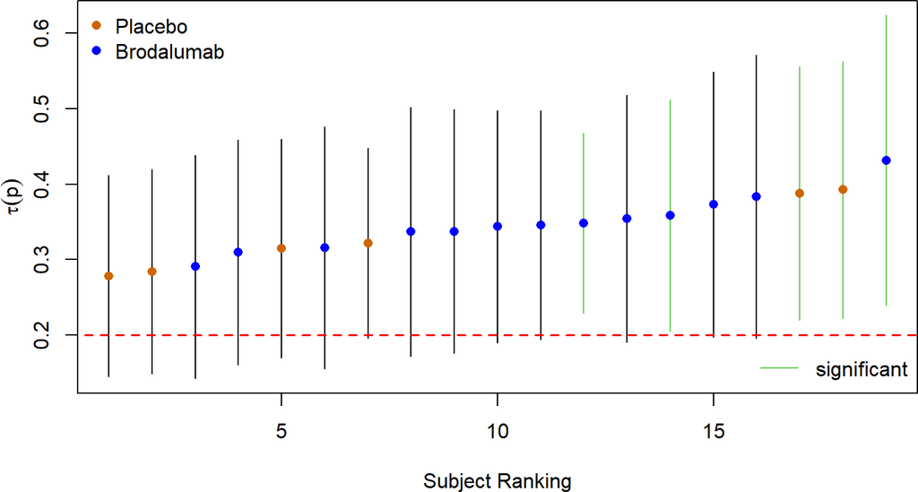

```r
plotPredict(pso, lb=expression(tau(p)),
            ctrl.plot = list(lb=c("Placebo", "Brodalumab"),
                             wht="topleft", whs = "bottomright"))
```

This is a prediction of the benefit of treating with brodalumab over placebo for each individual at baseline, based on the individual’s gene transcription of non-lesional skin. Not treated refers to patients who ended up receiving placebo, and treated to those that took brodalumab. We can compare the estimated benefit with the observed improvement after week 12.

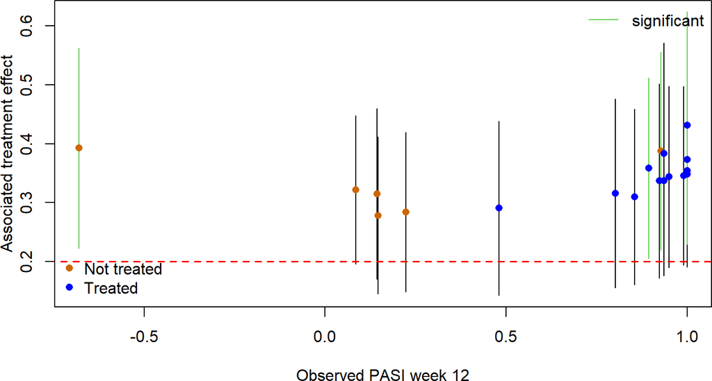

```r
plotPredict(pso, rk =pasiw12, xlab="Observed PASI week 12")
```

The relationship between estimated individual treatment effect and observed PASI reduction levels is better analyzed with a logistic relationship using the `drc` package

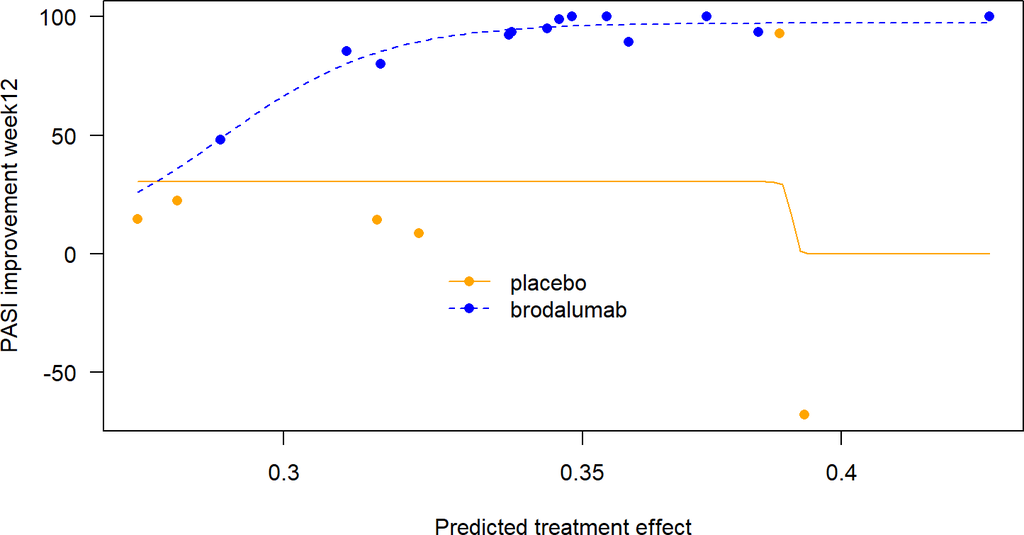

```r
library(drc)

response <- pasiw12[pso$subsids]
predictions <- pso$predictions
treatment <- factor(pso$treatment, labels = c("placebo", "brodalumab"))

mod <- drm(response*100~predictions, treatment, fct=LL.3())

plot(mod, pch=16, col=c("orange", "blue"),
     legendPos=c(0.36,-0.25),
     ylab="PASI improvement week12",
     xlab="Predicted treatment effect")
```

We see that while individuals receiving a placebo did not improve PASI, some would have strongly benefited from treatment. For individuals who ended up in brodalumab treatment, we can see a strong relationship between predicted treatment effect at baseline and the finally observed PASI improvement at week 12.